# Лабораторная работа №13

Фильтр пакетов

Хохлачева Полина Дмитриевна

Российский университет дружбы народов, Москва, Россия

# Информация

## Докладчик

- Хохлачева Полина Дмитриевна
- Российский университет дружбы народов
- Номер студенческого билета- 1132242473
- [1132242473@pfur.ru]

# Вводная часть

## Цель работы

Получить навыки настройки пакетного фильтра в Linux

## Выполнение лабораторной работы

Получаем полномочия администратора, определяем текущую зону по умолчанию, определяем доступные зоны(рис. [-@fig:001]).

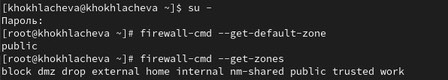

Зоны

## Выполнение лабораторной работы

Доступные службы на моём компьютере(рис. [-@fig:002]).

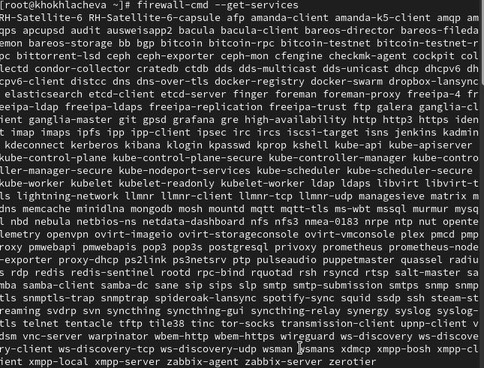

Службы

## Выполнение лабораторной работы

Информация, выводимая обеими командами, абсолютно идентична - нет никаких различий в отображаемых настройках firewall(рис. [-@fig:004]).

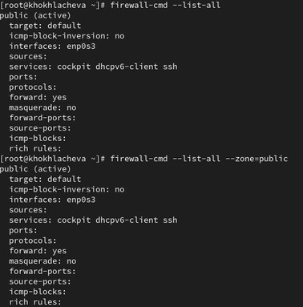

Информация

## Выполнение лабораторной работы

Добавляем сервер VNC в конфигурацию, проверяем добавился ли сервер в конфигурацию, перезапускаем службу(рис. [-@fig:005]).

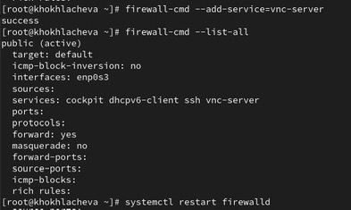

Добавление

## Выполнение лабораторной работы

vnc-server больше не указан, потому что правило добавили без параметра –permanent(рис. [-@fig:006]).

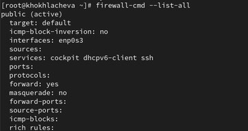

Параметр

## Выполнение лабораторной работы

Добавляем службу ещё раз и делаем её постоянной, проверяем наличия vnc-server в конфигурации, перезагружаем конфигурацию и смотрим конфигурацию времени выполнения(рис. [-@fig:007]).

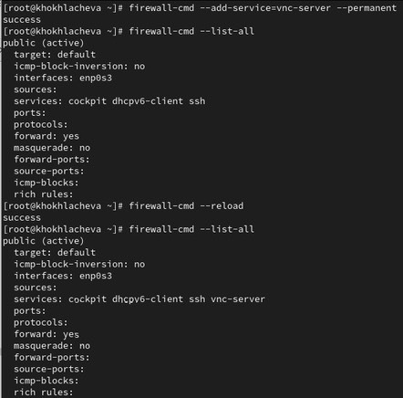

Добавление

## Выполнение лабораторной работы

Добавляем в конфигурацию порт 2022 протокола, перезагружаем конфигурацию, проверяем, что порт добавлен(рис. [-@fig:008]).

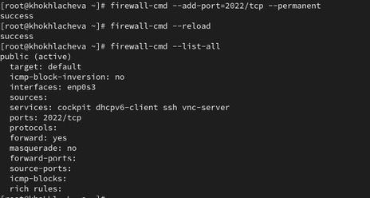

Добавление

## Выполнение лабораторной работы

В конфигурации выбираем “постоянная”, далее в public выбираем http, https и ftp(рис. [-@fig:009]).

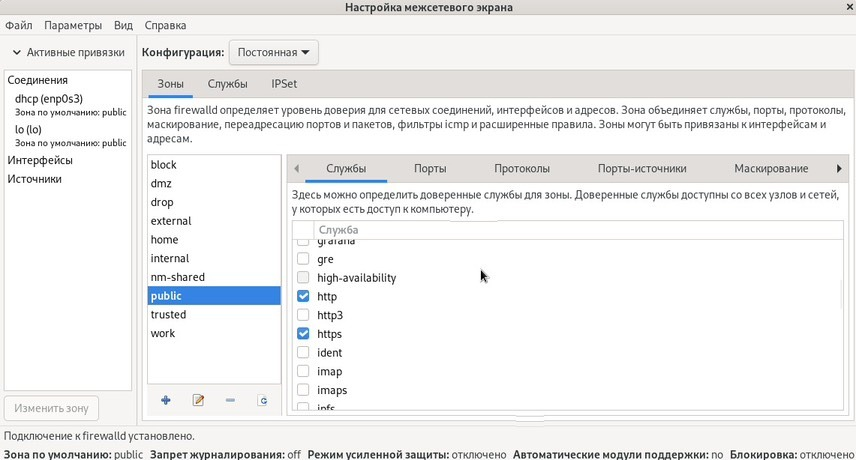

Конфигурация

## Выполнение лабораторной работы

Добавляем порт 2022 и протокол, чтобы добавить их в список(рис. [-@fig:011]).

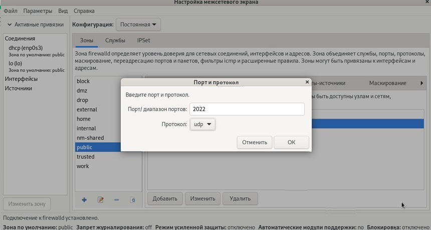

Добавление

## Выполнение лабораторной работы

Перезагружаем конфигурацию и список доступных сервисов, чтобы увидеть изменения((рис. [-@fig:012]).

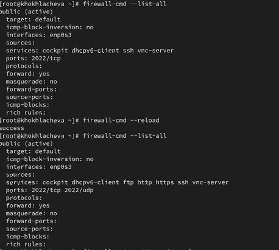

Изменения

# Выполнение самостоятельной работы

## Выполнение самостоятельной работы

В графическом интерфейсе выбираем imap, pop3, smtp(рис. [-@fig:014]).

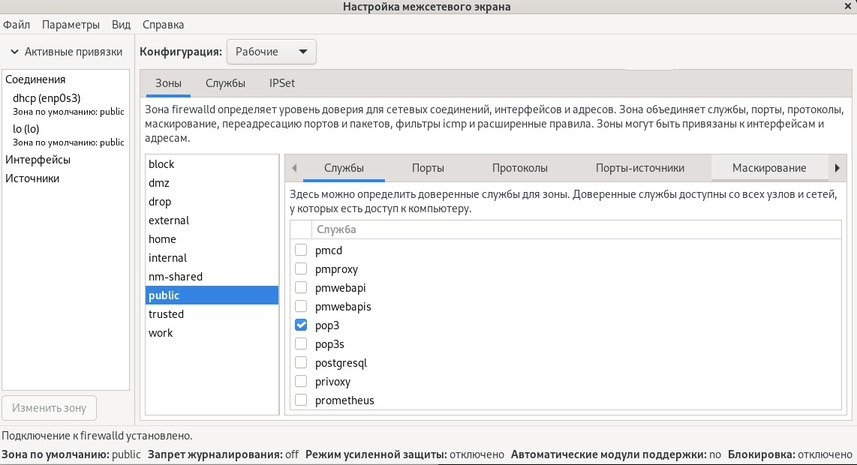

Выбор

## Выполнение самостоятельной работы

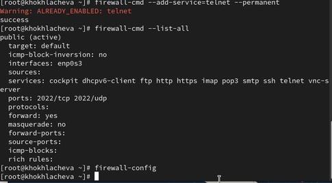

Выбор

# Выводы

Мы получили навыки настройки сетевых параметров системы.